# Predicting mortality after a prostate cancer diagnosis

## 0.1 Preliminaries

```r
library(arm)
library(leaps)
library(tableone)
library(pander)
library(ROCR)
library(skimr)
library(rms)
library(broom)
library(modelr)
library(GGally)
library(tidyverse)
```

# 1 Task 1: Data Source

These data come from a study done by Green and Byar (1980, Bulletin Cancer, Paris, 67, 477-488). Kay R. published on 1986 the results of this study, the article [can be found here](https://www.ncbi.nlm.nih.gov/pubmed/3521753) The data set is available in the [Department of Biostatistics, School of Medicine at Vanderbilt University](http://biostat.mc.vanderbilt.edu/wiki/Main/DataSets). The data set is (called `prostate.xls`).

This data `prostate.xls` The data set consists of 502 patients with prostate cancer in stages 3 and 4 who were randomly allocated to one of four treatment regimens: placebo, 0.2 mg, 1.0 mg, and 5.0 mg diethylstilbestrol (DES) daily. This clinical trial evaluated the effect of DES effect on survival and causes of death.

The original data contains 18 variables, but I will focus my analysis.made in a data subset called `prostate_subset.csv` that I create, which contains 10 variables, same 502 rows

# 2 Task 2: Load and Tidy the Data

## 2.1 Loading data

```r
prostate_subset <- read.csv("prostate_subset.csv") %>% tbl_df()
```

## 2.2 Tidying, data cleaning

I want to reorder the categoties of the variables `rx` and `status` in order to facilitate the analysis.

### 2.2.1 Refactoring variable rx and status

```r
prost <- prostate_subset %>%
    mutate(dead = ifelse(status == "alive", 0, 1),
           death_cau = fct_recode(status,
                                  cvc = "dead - heart or vascular",
                                  cvc = "dead - cerebrovascular",
                                  cvc = "dead - pulmonary embolus",
                                  cancer = "dead - prostatic ca",
                                  cancer = "dead - other ca",
                                  other = "dead - other specific non-ca",
                                  other = "dead - unknown cause",
                                  other = "dead - respiratory disease",
                                  other = "dead - unspecified non-ca"))

prost %>% count(status, dead, death_cau) # check to see if it worked
```

```
# A tibble: 10 x 4
   status                        dead death_cau     n
   <fct>                        <dbl> <fct>     <int>
 1 alive                         0    alive       148
 2 dead - cerebrovascular        1.00 cvc          31
 3 dead - heart or vascular      1.00 cvc          96
 4 dead - other ca               1.00 cancer       25
 5 dead - other specific non-ca  1.00 other        28
 6 dead - prostatic ca           1.00 cancer      130
 7 dead - pulmonary embolus      1.00 cvc          14
 8 dead - respiratory disease    1.00 other        16
 9 dead - unknown cause          1.00 other         7
10 dead - unspecified non-ca     1.00 other         7
```

```r
prost$tto <-
forcats::fct_recode(prost$rx, "high" = "5.0 mg estrogen", "low" = "1.0 mg estrogen", "low" = "0.2 mg estrogen", "placebo" = "placebo")
```

```r
table(prost$tto, prostate_subset$rx)
```

```
          0.2 mg estrogen 1.0 mg estrogen 5.0 mg estrogen placebo
  low                 124             126               0       0
  high                  0               0             125       0
  placebo               0               0               0     127
```

I recode the variable `rx`, create a new variable called `tto` and collapse 1.0 mg estrogen and 0.2 mg estrogen in the category `low` (low dose), and 5 mg estrogen in the category `high` (high dose). Low dose of DES is considerated 1 mg daily or less, according to this publication (https://www.ncbi.nlm.nih.gov/pubmed/21795073)

From the variable status, I created 2 new variables dead= 1:yes, 0:no. The other new variable is death_cau: to describe the cause of death, I grouped them by cardiovascular diseases (`cvs`), cancer (`cancer`) or other causes (`other`).

### 2.2.2 Identifying missing values

```r
na.pattern(prost)
```

```
pattern
0000000000000 0000000100000 0000100000000 0001000000000
          494             5             2             1
```

```r
prost %>%
    filter(rowSums(is.na(.)) > 0)
```

```
# A tibble: 8 x 13
  patno rx      status      age    wt    hx    hg    sz     ap    bm  dead
  <int> <fct>   <fct>     <int> <int> <int> <dbl> <int>  <dbl> <int> <dbl>
1    42 1.0 mg… alive        NA    76     0  12.8    35 30.0       1  0
2    48 5.0 mg… dead - u…    59   116     0  15.2    NA  0.700     0  1.00
3    74 0.2 mg… alive        72   142     1  12.6    NA  0.500     0  0
4   131 0.2 mg… dead - h…    76    94     0  14.2    NA  0.300     0  1.00
5   158 placebo dead - p…    68    98     0  15.0    NA  1.70      0  1.00
6   193 placebo alive        68    NA     1  14.6    18  0.200     0  0
7   262 placebo alive        73    NA     0  13.3    20  1.10      0  0
8   485 1.0 mg… alive        50   117     0  15.3    NA 10.3       0  0
# ... with 2 more variables: death_cau <fct>, tto <fct>
```

494 patients are missing nothing: these are the “complete cases”

Age value is missing in one subject (# 42). sz value is missing 5 different subjets (# 48, 74, 131, 158 and 485). wt is missing in 2 different subjects (# 193 and 262). This doesn’t have any repetitive patter. Missing data is only 1.6% of the data.

In my analyses, I will work with complete cases or I will do single imputations, I think either way will yield to similar results. The final tibble will display the missing values as NA.

# 3 Task 3: Listing of My Tibble

```r
skim_with(numeric = list(hist = NULL), integer = list(hist = NULL))
skim(prost)
```

```
Skim summary statistics
 n obs: 502
 n variables: 13

Variable type: factor
  variable missing complete   n n_unique
 death_cau       0      502 502        4
        rx       0      502 502        4
    status       0      502 502       10
       tto       0      502 502        3
                                      top_counts ordered
 can: 155, ali: 148, cvc: 141, oth: 58             FALSE
                           pla: 127, 1.0: 126, 5   FALSE
  ali: 148, dea: 130, dea: 96, dea: 31             FALSE
   low: 250, pla: 127, hig: 125, NA: 0             FALSE

Variable type: integer
 variable missing complete   n   mean     sd p0    p25 median    p75 p100
      age       1      501 502  71.46   7.08 48  70      73    76      89
       bm       0      502 502   0.16   0.37  0   0       0     0       1
       hx       0      502 502   0.42   0.49  0   0       0     1       1
    patno       0      502 502 251.72 145.42  1 126.25  251.5 376.75  506
       sz       5      497 502  14.63  12.32  0   5      11    21      69
       wt       2      500 502  99.03  13.44 69  90      98   107     152

Variable type: numeric
 variable missing complete   n  mean    sd  p0  p25 median   p75    p100
       ap       0      502 502 12.18 62.17 0.1  0.5    0.7  2.97  999.88
     dead       0      502 502  0.71  0.46 0    0      1    1       1
       hg       0      502 502 13.45  1.95 5.9 12.3   13.7 14.7    21.2
```

```r
glimpse(prost)
```

```
Observations: 502
Variables: 13
$ patno     <int> 1, 2, 3, 4, 5, 6, 7, 8, 9, 10, 11, 12, 13, 14, 15, 1...
$ rx        <fct> 0.2 mg estrogen, 0.2 mg estrogen, 5.0 mg estrogen, 0...
$ status    <fct> alive, dead - other ca, dead - cerebrovascular, dead...
$ age       <int> 75, 54, 69, 75, 67, 71, 75, 73, 60, 78, 77, 74, 74, ...
$ wt        <int> 76, 116, 102, 94, 99, 98, 100, 114, 110, 107, 89, 10...
$ hx        <int> 0, 0, 1, 1, 0, 0, 0, 1, 0, 1, 0, 1, 0, 1, 0, 1, 0, 0...
$ hg        <dbl> 13.79883, 14.59961, 13.39844, 17.59766, 13.39844, 15...
$ sz        <int> 2, 42, 3, 4, 34, 10, 13, 3, 4, 21, 3, 6, 6, 4, 15, 3...
$ ap        <dbl> 0.2999878, 0.6999512, 0.2999878, 0.8999023, 0.500000...
$ bm        <int> 0, 0, 0, 0, 0, 0, 0, 0, 0, 0, 0, 0, 0, 0, 0, 0, 0, 0...
$ dead      <dbl> 0, 1, 1, 1, 0, 1, 1, 0, 0, 0, 0, 0, 0, 1, 1, 1, 0, 1...
$ death_cau <fct> alive, cancer, cvc, cvc, alive, cancer, cvc, alive, ...
$ tto       <fct> low, low, high, low, placebo, low, placebo, placebo,...
```

This tibble has 502 subjects and 13 variables

# 4 Task 4: Code Book

[output not shown]

```r
tableOne <- CreateTableOne(data = prost,
               factorVars = c("hx", "bm", "dead",
                              "dead_cau", "tto"))
summary(tableOne)
```

```
     ### Summary of continuous variables ###

strata: Overall
        n miss p.miss mean  sd median   p25 p75  min  max   skew  kurt
patno 502    0    0.0  252 145  251.5 126.2 377  1.0  506  0.008  -1.2
age   502    1    0.2   71   7   73.0  70.0  76 48.0   89 -1.058   1.1
wt    502    2    0.4   99  13   98.0  90.0 107 69.0  152  0.546   0.8
hg    502    0    0.0   13   2   13.7  12.3  15  5.9   21 -0.438   0.8
sz    502    5    1.0   15  12   11.0   5.0  21  0.0   69  1.353   1.9
ap    502    0    0.0   12  62    0.7   0.5   3  0.1 1000 10.981 147.8

=======================================================================================

     ### Summary of categorical variables ###

strata: Overall
       var   n miss p.miss                        level freq percent
        rx 502    0    0.0              0.2 mg estrogen  124    24.7
                                        1.0 mg estrogen  126    25.1
                                        5.0 mg estrogen  125    24.9
                                                placebo  127    25.3

    status 502    0    0.0                        alive  148    29.5
                                 dead - cerebrovascular   31     6.2
                               dead - heart or vascular   96    19.1
                                        dead - other ca   25     5.0
                           dead - other specific non-ca   28     5.6
                                    dead - prostatic ca  130    25.9
                               dead - pulmonary embolus   14     2.8
                             dead - respiratory disease   16     3.2
                                   dead - unknown cause    7     1.4
                              dead - unspecified non-ca    7     1.4

        hx 502    0    0.0                            0  289    57.6
                                                      1  213    42.4

        bm 502    0    0.0                            0  420    83.7
                                                      1   82    16.3

      dead 502    0    0.0                            0  148    29.5
```

[output cut: 30 more lines]

```

        83.7
       100.0

        29.5
       100.0

        29.5
        57.6
        88.4
       100.0

        49.8
        74.7
       100.0
```

# 5 Task 5: My Subjects

The data describes a sample of 502 subjects with prostate cancer in stages 3 and 4 who were part of a clinical trial. They were randomly allocated to one of four treatment regimens: placebo, 0.2 mg, 1.0 mg, and 5.0 mg DES daily. The results of this trial were published in 1980. I coudn’t find the original paper to describe inclusion and exclusion criteria, follow-up time, etc.

# 6 Task 6: My Variables

There are 13 variables in the `prost` data set

# 7 Task 7: My Planned Linear Regression Model

- `age`
- `tto`
- `ap`
- `bm`
- `wt`
- `death_cau`

I can anticipate the concentration of prostatic acid phosphatase `ap` and the presence of bone metastasis `bm` may have a stronger association with tumor size `sz`

## 7.1 Spearman $\rho^2$ Plot

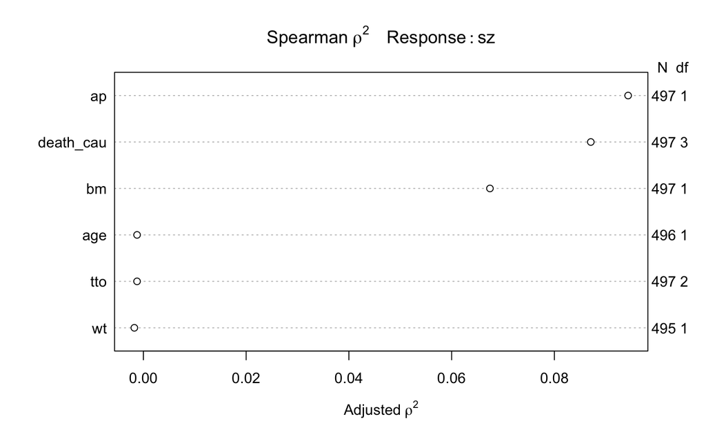

```r
plot(spearman2(sz ~ age + tto + ap + bm + wt + death_cau, data = prost))
```

The Spearman $\rho^2$ plot suggests that death_cau is an important predictor too. It looks like age, tto and wt have less importance.

# 8 Task 8: My Planned Logistic Regression Model

I will predict the binary outcome **dead** using some combination of the following 8 variables:

- `age`
- `tto`
- `ap`
- `bm`
- `wt`
- `sz`
- `hg`
- `hx`

## 8.1 Spearman $\rho^2$ Plot

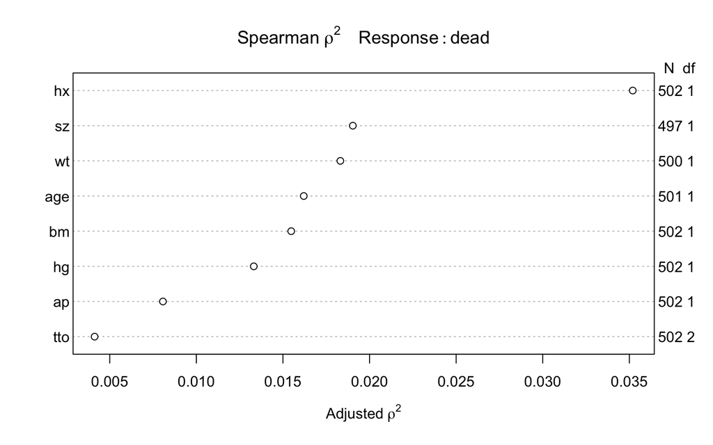

```r
plot(spearman2(dead ~ age + tto + ap + bm + wt  + sz + hg + hx, data = prost))
```

The Spearman $\rho^2$ plot suggests that hx is an important predictor, followed by sz, wt, age and bm. It looks like ap and tto have less importance.

# 9 Task 9: Affirmation

- I am certain that this data set meets all of the requirements specified and is completely appropriate to shared it with anyone, without any conditions. There are no concerns about privacy or security.

# 10 Task 10 Analysis: Linear Regression

Let’s start with kitchen sink model.

```r
ks_model <- lm(sz ~ age + tto + ap + bm + wt + death_cau, data = prost)
summary(ks_model)
```

```
Call:
lm(formula = sz ~ age + tto + ap + bm + wt + death_cau, data = prost)

Residuals:
    Min      1Q  Median      3Q     Max
-22.854  -7.819  -2.741   5.982  50.631

Coefficients:
                 Estimate Std. Error t value Pr(>|t|)
(Intercept)      3.958144   7.000902   0.565    0.572
age              0.077415   0.075613   1.024    0.306
ttohigh         -0.204525   1.288483  -0.159    0.874
ttoplacebo       0.156846   1.278452   0.123    0.902
ap              -0.001407   0.008737  -0.161    0.872
bm               6.453854   1.533199   4.209 3.05e-05 ***
wt               0.013417   0.040040   0.335    0.738
death_caucvc     0.450536   1.406561   0.320    0.749
death_caucancer  7.929985   1.380586   5.744 1.64e-08 ***
death_cauother   1.035415   1.830514   0.566    0.572
---
Signif. codes:  0 '***' 0.001 '**' 0.01 '*' 0.05 '.' 0.1 ' ' 1

Residual standard error: 11.51 on 484 degrees of freedom
  (8 observations deleted due to missingness)
Multiple R-squared:  0.1437,    Adjusted R-squared:  0.1278
F-statistic: 9.026 on 9 and 484 DF,  p-value: 1.188e-12
```

I am going to modified the kitchen sink model according to the Spearman ρ2 plot.

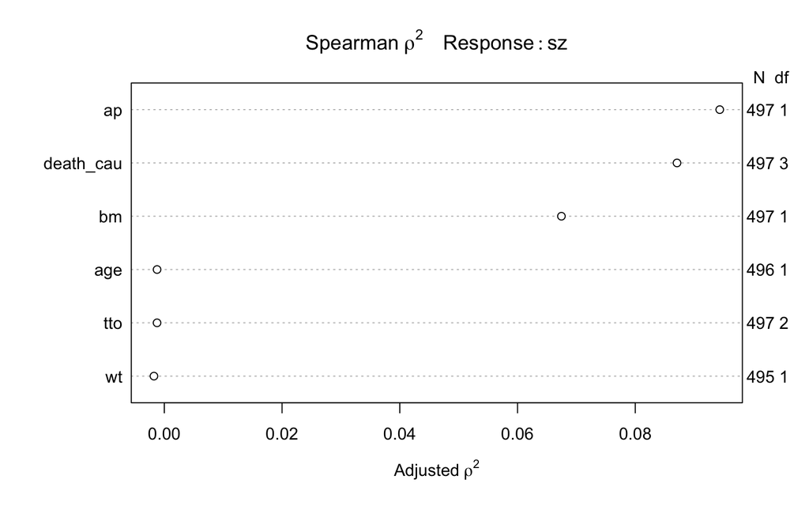

```r
plot(spearman2(sz ~ age + tto + ap + bm + wt + death_cau, data = prost))
```

Let’s start with a model with the most apparent important variable ap, followed by death_cau and bm. I will also include a restricted cubic spline with 4 knots in ap, and an interaction between ap and death_cau, followerd by the other candidate predictors: age, tto, wt.

```r
d <- datadist(prost)
options(datadist = "d")

km_modified <- ols(sz ~ rcs(ap, 4) * death_cau + catg(bm) + age + tto + wt,
           data = prost, x = T, y = T)
km_modified
```

```
Frequencies of Missing Values Due to Each Variable
       sz        ap death_cau        bm       age       tto        wt
        5         0         0         0         1         0         2

Linear Regression Model

 ols(formula = sz ~ rcs(ap, 4) * death_cau + catg(bm) + age +
     tto + wt, data = prost, x = T, y = T)


                 Model Likelihood     Discrimination
                    Ratio Test           Indexes
 Obs      494    LR chi2    100.85    R2       0.185
 sigma11.3615    d.f.           20    R2 adj   0.150
 d.f.     473    Pr(> chi2) 0.0000    g        5.764

 Residuals

     Min      1Q  Median      3Q     Max
 -23.074  -7.309  -2.204   5.344  51.581


                         Coef       S.E.       t     Pr(>|t|)
 Intercept                   2.9319     8.0517  0.36 0.7159
 ap                          5.1288     6.9060  0.74 0.4581
 ap'                     -7329.7519 11482.9352 -0.64 0.5236
 ap''                    10460.4246 16408.8766  0.64 0.5241
 death_cau=cvc              -0.5696     5.2054 -0.11 0.9129
 death_cau=cancer            8.6843     5.8535  1.48 0.1386
 death_cau=other            -0.2354     6.4115 -0.04 0.9707
 bm=1                        3.2121     1.6890  1.90 0.0578
 age                         0.0462     0.0760  0.61 0.5439
 tto=high                   -0.2113     1.2875 -0.16 0.8697
 tto=placebo                 0.1228     1.2759  0.10 0.9234
 wt                          0.0129     0.0398  0.32 0.7461
 ap * death_cau=cvc          1.7600     9.2712  0.19 0.8495
 ap' * death_cau=cvc     -2798.1654 15597.5648 -0.18 0.8577
 ap'' * death_cau=cvc     3997.6569 22293.3759  0.18 0.8578
 ap * death_cau=cancer      -3.1431     9.9579 -0.32 0.7524
 ap' * death_cau=cancer   5039.3940 16469.5446  0.31 0.7598
 ap'' * death_cau=cancer -7199.0175 23533.5090 -0.31 0.7598
 ap * death_cau=other        2.0069    11.9430  0.17 0.8666
 ap' * death_cau=other   -2558.1894 19892.9225 -0.13 0.8977
 ap'' * death_cau=other   3647.0696 28427.1976  0.13 0.8980
```

```r
summary(km_modified)
```

```
             Effects              Response : sz

 Factor                   Low  High    Diff.  Effect   S.E.    Lower 0.95
 ap                        0.5   2.975  2.475  1.69270 1.58110  -1.41420
 age                      70.0  76.000  6.000  0.27702 0.45615  -0.61932
 wt                       90.0 107.000 17.000  0.21918 0.67659  -1.11030
 death_cau - alive:cancer  3.0   1.000     NA -6.70070 1.71140 -10.06400
 death_cau - cvc:cancer    3.0   2.000     NA -6.15840 1.81530  -9.72550
 death_cau - other:cancer  3.0   4.000     NA -5.64120 2.44110 -10.43800
 bm - 1:0                  1.0   2.000     NA  3.21210 1.68900  -0.10680
 tto - high:low            1.0   2.000     NA -0.21132 1.28750  -2.74130
 tto - placebo:low         1.0   3.000     NA  0.12278 1.27590  -2.38430
 Upper 0.95
  4.79960
  1.17340
  1.54870
 -3.33780
 -2.59140
 -0.84438
  6.53100
  2.31870
  2.62990

Adjusted to: ap=0.6999512 death_cau=cancer
```

[output not shown]